# gapminder

## # 4 GDP per capita (50pt)

#Let’s look at GDP per capita (GDP_PC). #1. (8pt) Make a scatterplot of GDP per capita versus life expectancy by country, using data for #1960. Make the point size dependent on the country size, and #color those according to the #continent. Feel free to adjust the plot in other ways to make #it better. Comment what do you see there.

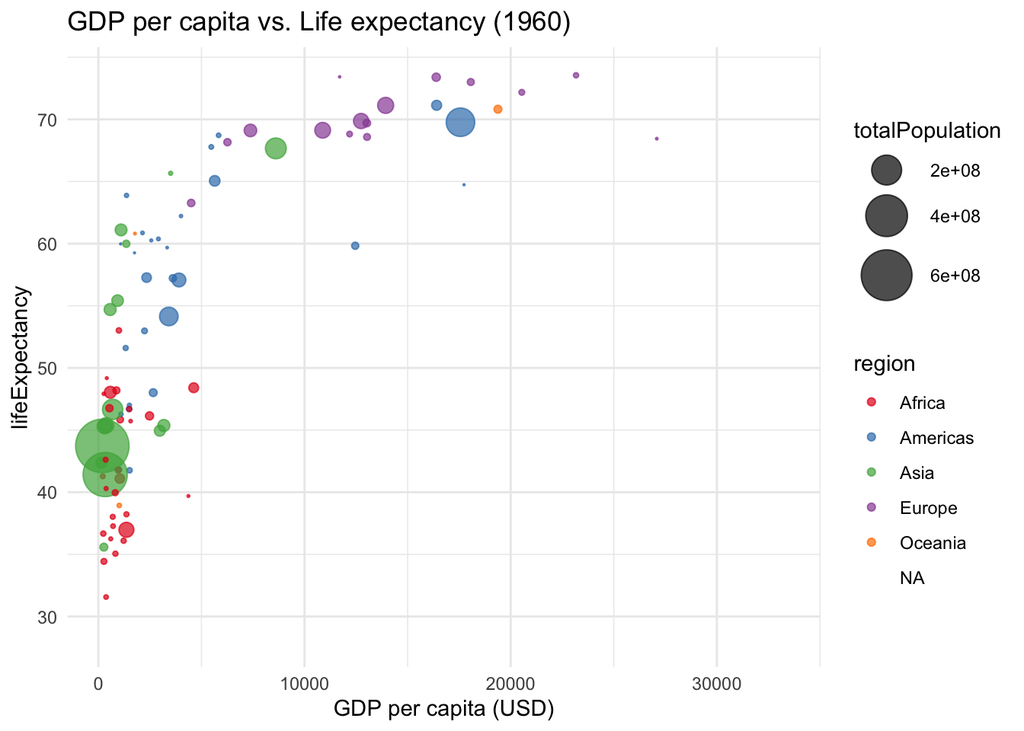

```r
gapminder_1960 <- gap %>% filter(time == 1960)
ggplot(gapminder_1960, aes(x = GDP_PC, y = lifeExpectancy, size = totalPopulation, color = region)) +
  geom_point(alpha = 0.7) +
  scale_size_area(max_size = 12) +
  scale_color_brewer(palette = "Set1") +
  labs(x = "GDP per capita (USD)", Y = "Life expectancy (years)", title = "GDP per capita vs. Life expectancy (1960)") +
  theme_minimal()
```

#2. (4pt) Make a similar plot, but this time use 2019 data only.

[figure not shown]

```r
gapminder_1960 <- gap %>% filter(time == 2019)
ggplot(gapminder_1960, aes(x = GDP_PC, y = lifeExpectancy, size = totalPopulation, color = region)) +
  geom_point(alpha = 0.7) +
  scale_size_area(max_size = 12) +
  scale_color_brewer(palette = "Set1") +
  labs(x = "GDP per capita (USD)", Y = "Life expectancy (years)", title = "GDP per capita vs. Life expectancy (1960)") +
  theme_minimal()
```

#3. (6pt) Compare these two plots and comment what do you see. How has world developed through the last 60 years? As GDP per capita increase, lifeExpectancy also increased. There is a radical increasing point at about 15000.

#4. (6pt) Compute the average life expectancy for each continent in 1960 and 2019. Do the results fit with what do you see on the figures? #Note: here as average I mean just average over countries, #ignore the fact that countries are of different size.

```r
data_1960 <- gap %>% filter (time == 1960)  %>% filter (!is.na(lifeExpectancy))
mean(data_1960$lifeExpectancy)
```

```
## [1] 53.89823
```

```r
data_2019 <- gap %>% filter (time == 2019)  %>% filter (!is.na(lifeExpectancy))
mean(data_2019$lifeExpectancy)
```

```
## [1] 72.9269
```

#6. (6pt) Show the histogram of GDP per capita for years of 1960 and 2019. Try to put both histograms on the same graph, see how well you can do it!

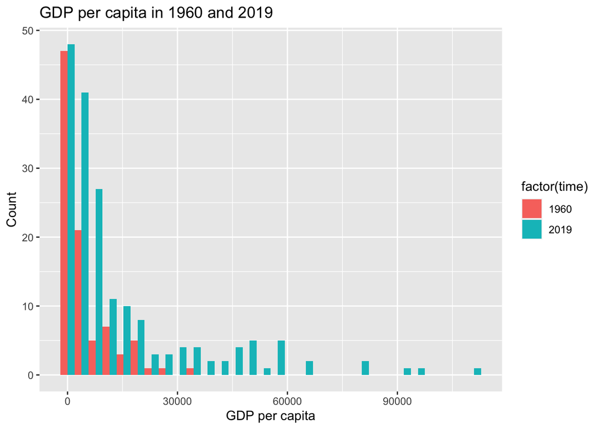

```r
gdp_data <- gap %>%
  filter(!is.na(GDP_PC), time %in% c(1960, 2019))

ggplot(gdp_data, aes(x = GDP_PC, fill = factor(time))) +
  geom_histogram(position = "dodge") +
  labs(x = "GDP per capita", y = "Count") +
  ggtitle("GDP per capita in 1960 and 2019")
```

#7. (6pt) What was the ranking of US in terms of life expectancy in 1960 and in 2019? (When #counting from top.) #Hint: check out the function rank()! #Hint2: 17 for 1960.

```r
gap %>%
    select(name, time, lifeExpectancy) %>%
    filter(name != "", !is.na(time), !is.na(lifeExpectancy)) %>%
    filter(time == "1960") %>%
    mutate(rank = rank(desc(lifeExpectancy))) %>%
    filter(name == "United States of America")
```

```
## # A tibble: 1 × 4
##   name                      time lifeExpectancy  rank
##   <chr>                    <dbl>          <dbl> <dbl>
## 1 United States of America  1960           69.8    17
```

#8. (6pt) If you did this correctly, then you noticed that US ranking has been falling quite a bit. But we also have more countries in 2019–what about the relative rank divided by the corresponding number of countries that have LE data in the corresponding year? Hint: 0.0904 for 1960.

```r
gp_2019 <- gap %>%
  filter(name != "", !is.na(time), !is.na(lifeExpectancy)) %>%
  filter(time == "2019") %>%
  mutate(rank = rank(desc(lifeExpectancy)))
us_2019 <- gp_2019 %>%
  filter(name == "United States of America")
rel_rank <- us_2019$rank / n_distinct(gp_2019$name)
rel_rank
```

```
## [1] 0.2346939
```